# European history in a nutshell - parte 2

Caronte Martina, Lo Giudice Federica, Sisti Sara

#### Installazione librerie

```r
library(tidyverse)
library(rvest)
library(magrittr)
library(rJava)
library(coreNLP)
library(NLP)
library(openNLP)
library(textclean)
library(tm)
library(wordcloud2)
library(dplyr)
library(text2vec)
library(RColorBrewer)
library(data.table)
library(monkeylearn)
library(leaflet)
library(utf8)
library(stringr)
library(networkD3)
library(dygraphs)
library(xts)
library(lexicon)
```

#### Webscraping

Abbiamo deciso di utilizzare la tecnica del webscraping ai fini di costruire il nostro dataset. Lo scraping è stato applicato a 60 pagine Wikipedia riguardanti 60 tra le più note città europee (elencate in [questo file](https://raw.githubusercontent.com/sarasixti/SLproject/master/dataset_cities_clean.txt)), di cui abbiamo scaricato la sezione riguardante la storia. Abbiamo creato una funzione **texts** che performa lo scraping prendendo come input la categoria (“history” in questo caso), gli indici dei paragrafi della categoria sulla pagina html Wikipedia, l’url della pagina. Abbiamo infine organizzato i testi ottenuti in un dataframe con 2 variabili contenenti: nome della città, testo.

```r
cities <- fread("https://raw.githubusercontent.com/sarasixti/SLproject/master/dataset_cities_clean.txt")
country<-cities$country
city_list<-cities$city
city_list<-city_list[-which(city_list=="Chisinau")]
city_list<-city_list[-which(city_list=="Monte Carlo")]
city_list<-city_list[-which(city_list=="Braga")]

categ <- "history"

texts<-function(category,indexes,city){
  base_url <- paste0("https://en.wikipedia.org/wiki/", city)
  webpage <- read_html(base_url)
  xpaths<-sapply(indexes,function(i) paste0('//*[@id="mw-content-text"]/div/p[',i,']'))
  category<-c()
  for (p in 1:length(xpaths)){
    category<-c(category,webpage %>% html_nodes(xpath = xpaths[p]) %>% html_text())
  }
  category<-gsub("\n", "", category)
  category<-paste(unlist(category),collapse="")
  return(category)
}

dataset_finale<-matrix(NA,nrow=length(city_list),ncol=length(categ))
colnames(dataset_finale)<-categ

#fill rows with history texts:
#Tirana
city<-city_list[1]
row<-which(city_list==city)
indexes_hist<-c(7:22)
history<-texts(categ[1],indexes_hist,city)
tirana_row<-matrix(history,nrow=1,ncol=length(categ))
dataset_finale[row,]<-tirana_row

#Vienna
city<-city_list[2]
row<-which(city_list==city)
indexes_hist<-c(10:25)
history<-texts(categ[1],indexes_hist,city)
vienna_row<-matrix(history,nrow=1,ncol=length(categ))
dataset_finale[row,]<-vienna_row

#Minsk
city<-city_list[3]
row<-which(city_list==city)
indexes_hist<-c(8:29)
history<-texts(categ[1],indexes_hist,city)
minsk_row<-matrix(history,nrow=1,ncol=length(categ))
colnames(minsk_row)<-categ
rownames(minsk_row)<-city
dataset_finale[row,]<-minsk_row

#Brussels
city<-city_list[4]
row<-which(city_list==city)
indexes_hist<-c(9:23)
history<-texts(categ[1],indexes_hist,city)
bruss_row<-matrix(history,nrow=1,ncol=length(categ))
dataset_finale[row,]<-bruss_row

#Antwerp
city<-city_list[5]
row<-which(city_list==city)
indexes_hist<-c(5:26)
history<-texts(categ[1],indexes_hist,city)
antwerp_row<-matrix(history,nrow=1,ncol=length(categ))
dataset_finale[row,]<-antwerp_row

#Sarajevo
city<-city_list[6]
row<-which(city_list==city)
indexes_hist<-c(19:53)
history<-texts(categ[1],indexes_hist,city)
sarajevo_row<-matrix(history,nrow=1,ncol=length(categ))
dataset_finale[row,]<-sarajevo_row

#Sofia
city<-city_list[7]
row<-which(city_list==city)
indexes_hist<-c(19:43)
history<-texts(categ[1],indexes_hist,city)
sofia_row<-matrix(history,nrow=1,ncol=length(categ))
dataset_finale[row,]<-sofia_row

#zagreb
city<-city_list[8]
row<-which(city_list==city)
indexes_hist<-c(10:25)
history<-texts(categ[1],indexes_hist,city)
zagreb_row<-matrix(history,nrow=1,ncol=length(categ))
dataset_finale[row,]<-zagreb_row

#Nicosia
city<-city_list[9]
row<-which(city_list==city)
indexes_hist<-c(6:29)#change
history<-texts(categ[1],indexes_hist,city)
nicosia_row<-matrix(history,nrow=1,ncol=length(categ))
dataset_finale[row,]<-nicosia_row

#prague
city<-city_list[10]
row<-which(city_list==city)
indexes_hist<-c(7:41)
history<-texts(categ[1],indexes_hist,city)
prague_row<-matrix(history,nrow=1,ncol=length(categ))
dataset_finale[row,]<-prague_row

#Copenhagen
city<-city_list[11]
row<-which(city_list==city)
indexes_hist<-c(9:35)
history<-texts(categ[1],indexes_hist,city)
copen_row<-matrix(history,nrow=1,ncol=length(categ))
dataset_finale[row,]<-copen_row

#Tallin
city<-city_list[12]
row<-which(city_list==city)
indexes_hist<-c(14:31)
history<-texts(categ[1],indexes_hist,city)
tallin_row<-matrix(history,nrow=1,ncol=length(categ))
dataset_finale[row,]<-tallin_row

#Helsinki
city<-city_list[13]
row<-which(city_list==city)
indexes_hist<-c(10:19)
history<-texts(categ[1],indexes_hist,city)
helsin_row<-matrix(history,nrow=1,ncol=length(categ))
dataset_finale[row,]<-helsin_row

#paris
city<-city_list[14]
row<-which(city_list==city)
indexes_hist<-c(10:41)
history<-texts(categ[1],indexes_hist,city)
paris_row<-matrix(history,nrow=1,ncol=length(categ))
dataset_finale[row,]<-paris_row

#Lyon
city<-city_list[15]
row<-which(city_list==city)
indexes_hist<-c(5:14)
history<-texts(categ[1],indexes_hist,city)
lyon_row<-matrix(history,nrow=1,ncol=length(categ))
dataset_finale[row,]<-lyon_row

#Marseille
city<-city_list[16]
row<-which(city_list==city)
indexes_hist<-c(9:11)
history<-texts(categ[1],indexes_hist,city)
marseille_row<-matrix(history,nrow=1,ncol=length(categ))
dataset_finale[row,]<-marseille_row


#Cologne
city<-city_list[17]
row<-which(city_list==city)
indexes_hist<-c(6:33)
history<-texts(categ[1],indexes_hist,city)
cologne_row<-matrix(history,nrow=1,ncol=length(categ))
dataset_finale[row,]<-cologne_row


#Berlin
city<-city_list[18]
row<-which(city_list==city)
indexes_hist<-c(8:22)
history<-texts(categ[1],indexes_hist,city)
berlin_row<-matrix(history,nrow=1,ncol=length(categ))
dataset_finale[row,]<-berlin_row

#Francoforte
city<-city_list[19]
row<-which(city_list==city)
indexes_hist<-c(18:38)#change
history<-texts(categ[1],indexes_hist,city)
frank_row<-matrix(history,nrow=1,ncol=length(categ))
dataset_finale[row,]<-frank_row

#Atene
city<-city_list[20]
row<-which(city_list==city)
indexes_hist<-c(10:18)
history<-texts(categ[1],indexes_hist,city)
athen_row<-matrix(history,nrow=1,ncol=length(categ))
dataset_finale[row,]<-athen_row

#Budapest
city<-city_list[21]
row<-which(city_list==city)
indexes_hist<-c(12:23)
history<-texts(categ[1],indexes_hist,city)
budapest_row<-matrix(history,nrow=1,ncol=length(categ))
dataset_finale[row,]<-budapest_row

#Reykjavik
city<-city_list[22]
row<-which(city_list==city)
indexes_hist<-c(3:12)
indexes_econ<-c(29:30)
indexes_cult<-c(37:43)
indexes_culin<-c(43)
history<-texts(categ[1],indexes_hist,city)
rey_row<-matrix(history,nrow=1,ncol=length(categ))
dataset_finale[row,]<-rey_row

#Dublin
city<-city_list[23]
row<-which(city_list==city)
indexes_hist<-c(7:21)
history<-texts(categ[1],indexes_hist,city)
dublin_row<-matrix(history,nrow=1,ncol=length(categ))
dataset_finale[row,]<-dublin_row

#Milan
city<-city_list[24]
row<-which(city_list==city)
indexes_hist<-c(7:23)
history<-texts(categ[1],indexes_hist,city)
milan_row<-matrix(history,nrow=1,ncol=length(categ))
dataset_finale[row,]<-milan_row
```

```r
#Naples
city<-city_list[25]
row<-which(city_list==city)
indexes_hist<-c(9:33)
history<-texts(categ[1],indexes_hist,city)
naples_row<-matrix(history,nrow=1,ncol=length(categ))
dataset_finale[row,]<-naples_row

#Rome
city<-city_list[26]
row<-which(city_list==city)
indexes_hist<-c(8:38)
history<-texts(categ[1],indexes_hist,city)
rome_row<-matrix(history,nrow=1,ncol=length(categ))
dataset_finale[row,]<-rome_row

#Riga
city<-city_list[27]
row<-which(city_list==city)
indexes_hist<-c(8:32)
history<-texts(categ[1],indexes_hist,city)
riga_row<-matrix(history,nrow=1,ncol=length(categ))
dataset_finale[row,]<-riga_row


#Vilinius
city<-city_list[28]
row<-which(city_list==city)
history<-texts(categ[1],indexes_hist,city)
vilinius_row<-matrix(history,nrow=1,ncol=length(categ))
dataset_finale[row,]<-vilinius_row

#Lussemburgo
city<-city_list[29]
row<-which(city_list==city)
indexes_hist<-c(7:18)
history<-texts(categ[1],indexes_hist,city)
lux_row<-matrix(history,nrow=1,ncol=length(categ))
dataset_finale[row,]<-lux_row

#Valletta
city<-city_list[30]
row<-which(city_list==city)
indexes_hist<-c(5:23)
history<-texts(categ[1],indexes_hist,city)
valletta_row<-matrix(history,nrow=1,ncol=length(categ))
dataset_finale[row,]<-valletta_row

#Podgorica
city<-city_list[31]
row<-which(city_list==city)
indexes_hist<-c(20:30)
history<-texts(categ[1],indexes_hist,city)
podg_row<-matrix(history,nrow=1,ncol=length(categ))
dataset_finale[row,]<-podg_row

#Amsterdam
city<-city_list[32]
row<-which(city_list==city)
indexes_hist<-c(7:21)
history<-texts(categ[1],indexes_hist,city)
amsterdam_row<-matrix(history,nrow=1,ncol=length(categ))
dataset_finale[row,]<-amsterdam_row

#Rotterdam
city<-city_list[33]
row<-which(city_list==city)
indexes_hist<-c(5:11)
history<-texts(categ[1],indexes_hist,city)
rotterdam_row<-matrix(history,nrow=1,ncol=length(categ))
dataset_finale[row,]<-rotterdam_row

#Oslo
city<-city_list[34]
row<-which(city_list==city)
indexes_hist<-c(15:30)
history<-texts(categ[1],indexes_hist,city)
oslo_row<-matrix(history,nrow=1,ncol=length(categ))
dataset_finale[row,]<-oslo_row

#Bergen
city<-city_list[35]
row<-which(city_list==city)
indexes_hist<-c(5:18)
history<-texts(categ[1],indexes_hist,city)
bergen_row<-matrix(history,nrow=1,ncol=length(categ))
dataset_finale[row,]<-bergen_row

#Warsaw
city<-city_list[36]
row<-which(city_list==city)
indexes_hist<-c(9:28)
history<-texts(categ[1],indexes_hist,city)
warsaw_row<-matrix(history,nrow=1,ncol=length(categ))
dataset_finale[row,]<-warsaw_row

#Krakov
city<-city_list[37]
row<-which(city_list==city)
indexes_hist<-c(9:24)
history<-texts(categ[1],indexes_hist,city)
krakow_row<-matrix(history,nrow=1,ncol=length(categ))
dataset_finale[row,]<-krakow_row


#Lisbon
city<-city_list[38]
row<-which(city_list==city)
indexes_hist<-c(8:41)
history<-texts(categ[1],indexes_hist,city)
lisbon_row<-matrix(history,nrow=1,ncol=length(categ))
dataset_finale[row,]<-lisbon_row

#Porto
city<-city_list[39]
row<-which(city_list==city)
indexes_hist<-c(4:18)
history<-texts(categ[1],indexes_hist,city)
porto_row<-matrix(history,nrow=1,ncol=length(categ))
dataset_finale[row,]<-porto_row

#Bucharest
city<-city_list[40]
row<-which(city_list==city)
indexes_hist<-c(10:21)
history<-texts(categ[1],indexes_hist,city)
buch_row<-matrix(history,nrow=1,ncol=length(categ))
dataset_finale[row,]<-buch_row

#Moscow
city<-city_list[41]
row<-which(city_list==city)
indexes_hist<-c(15:56)
history<-texts(categ[1],indexes_hist,city)
moscow_row<-matrix(history,nrow=1,ncol=length(categ))
dataset_finale[row,]<-moscow_row

#st petersburg
city<-city_list[42]
row<-which(city_list==city)
indexes_hist<-c(8:44)
history<-texts(categ[1],indexes_hist,city)
stpeter_row<-matrix(history,nrow=1,ncol=length(categ))
dataset_finale[row,]<-stpeter_row

#Belgrade
city<-city_list[43]
row<-which(city_list==city)
indexes_hist<-c(5:34)
history<-texts(categ[1],indexes_hist,city)
belgrade_row<-matrix(history,nrow=1,ncol=length(categ))
dataset_finale[row,]<-belgrade_row

#Bratislava
city<-city_list[44]
row<-which(city_list==city)
indexes_hist<-c(11:29)
history<-texts(categ[1],indexes_hist,city)
bratis_row<-matrix(history,nrow=1,ncol=length(categ))
dataset_finale[row,]<-bratis_row

#Ljubljana
city<-city_list[45]
row<-which(city_list==city)
indexes_hist<-c(8:24)
history<-texts(categ[1],indexes_hist,city)
lj_row<-matrix(history,nrow=1,ncol=length(categ))
dataset_finale[row,]<-lj_row

#Madrid
city<-city_list[46]
row<-which(city_list==city)
indexes_hist<-c(10:25)
history<-texts(categ[1],indexes_hist,city)
madrid_row<-matrix(history,nrow=1,ncol=length(categ))
dataset_finale[row,]<-madrid_row

#barcelona
city<-city_list[47]
row<-which(city_list==city)
indexes_hist<-c(11:22)
history<-texts(categ[1],indexes_hist,city)
barcelona_row<-matrix(history,nrow=1,ncol=length(categ))
dataset_finale[row,]<-barcelona_row

#Valencia
city<-city_list[48]
row<-which(city_list==city)
indexes_hist<-c(53:80)
history<-texts(categ[1],indexes_hist,city)
valencia_row<-matrix(history,nrow=1,ncol=length(categ))
dataset_finale[row,]<-valencia_row

#Stoccolma
city<-city_list[49]
row<-which(city_list==city)
indexes_hist<-c(6:14)
history<-texts(categ[1],indexes_hist,city)
stock_row<-matrix(history,nrow=1,ncol=length(categ))
dataset_finale[row,]<-stock_row

#Zurich
city<-city_list[50]
row<-which(city_list==city)
indexes_hist<-c(11:26)
history<-texts(categ[1],indexes_hist,city)
zurich_row<-matrix(history,nrow=1,ncol=length(categ))
dataset_finale[row,]<-zurich_row

#Geneve
city<-city_list[51]
row<-which(city_list==city)
indexes_hist<-c(10:11)
history<-texts(categ[1],indexes_hist,city)
geneve_row<-matrix(history,nrow=1,ncol=length(categ))
dataset_finale[row,]<-geneve_row

#Basel
city<-city_list[52]
row<-which(city_list==city)
indexes_hist<-c(8:32)
history<-texts(categ[1],indexes_hist,city)
basel_row<-matrix(history,nrow=1,ncol=length(categ))
dataset_finale[row,]<-basel_row

#Istanbul
city<-city_list[53]
row<-which(city_list==city)
indexes_hist<-c(11:24)
history<-texts(categ[1],indexes_hist,city)
istanbul_row<-matrix(history,nrow=1,ncol=length(categ))
dataset_finale[row,]<-istanbul_row
```

```r
#Ankara
city<-city_list[54]
row<-which(city_list==city)
indexes_hist<-c(11:40)
history<-texts(categ[1],indexes_hist,city)
ankara_row<-matrix(history,nrow=1,ncol=length(categ))
dataset_finale[row,]<-ankara_row

#kyiv
city<-city_list[55]
row<-which(city_list==city)
indexes_hist<-c(12:27)
history<-texts(categ[1],indexes_hist,city)
kyiv_row<-matrix(history,nrow=1,ncol=length(categ))
dataset_finale[row,]<-kyiv_row

#london
city<-city_list[56]
row<-which(city_list==city)
indexes_hist<-c(11:34)
history<-texts(categ[1],indexes_hist,city)
london_row<-matrix(history,nrow=1,ncol=length(categ))
dataset_finale[row,]<-london_row

#Birmingham
city<-city_list[57]
row<-which(city_list==city)
indexes_hist<-c(8:29)
history<-texts(categ[1],indexes_hist,city)
birm_row<-matrix(history,nrow=1,ncol=length(categ))
dataset_finale[row,]<-birm_row

#Manchester
city<-city_list[58]
row<-which(city_list==city)
indexes_hist<-c(7:27)
history<-texts(categ[1],indexes_hist,city)
manch_row<-matrix(history,nrow=1,ncol=length(categ))
dataset_finale[row,]<-manch_row

#edinburgo
city<-city_list[59]
row<-which(city_list==city)
indexes_hist<-c(17:30)
history<-texts(categ[1],indexes_hist,city)
edinb_row<-matrix(history,nrow=1,ncol=length(categ))
dataset_finale[row,]<-edinb_row

#belfast
city<-city_list[60]
row<-which(city_list==city)
indexes_hist<-c(8:19)
history<-texts(categ[1],indexes_hist,city)
belfast_row<-matrix(history,nrow=1,ncol=length(categ))
dataset_finale[row,]<-belfast_row

dataset_finale<-cbind(city_list,dataset_finale)
```

#### Sezione “History influencers”

Per rispondere alla domanda “quali sono stati i personaggi più influenti della storia europea?” abbiamo:

1. Utilizzato nuovamente la libreria **monkeylearn**, che mette a disposizione anche un [estrattore di nomi propri](https://app.monkeylearn.com/main/extractors/ex_SmwSdZ3C/), che applica la tecnica detta **Named Entity Recognition (NER)**;

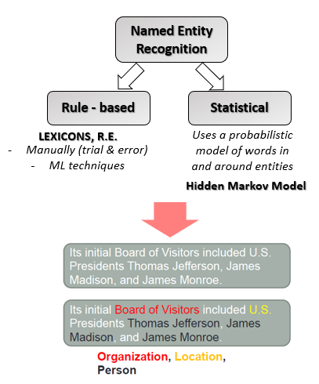

NER

```r
dataset_history<-as.data.frame(dataset_finale)
colnames(dataset_history)<-c("doc_id","text")

dataset_people<-matrix(0,nrow=60,ncol=2)
dataset_people<-as.data.frame(dataset_people)
colnames(dataset_people)<-c("city","people")
dataset_people$city<-dataset_history$doc_id


#NEED AN APIKEY!
#per comodità inseriamo il dataset di Named Entities già estratte,
#se volesse riprodurre questi risultati basta creare un account
#su monkeylearn e sostituire l'APIkey della funzione seguente
#con il nuovo APIkey.

# for (i in 1:nrow(dataset_history)){
#   text<-as.character(dataset_history[i,2])
#   people.city<-monkey_extract(text,extractor_id = "ex_SmwSdZ3C", key="e67d16c6d326228992516bf43b283a8683cd31ae")
#   persone<-people.city$entity
#   dataset_people[i,2]<- paste( unlist(persone), collapse=',')
# }

dataset_people<-read.csv2("https://raw.githubusercontent.com/sarasixti/SLproject/master/dataset_people_list.csv",stringsAsFactors = F,encoding="UTF-8")

unique_people<-c()
for (i in 1:nrow(dataset_people)){
  new<-unlist(strsplit(dataset_people[i,2],","))
  unique_people<-c(unique_people,new)
}
unique_people<-unique(unique_people)

dataset_people_large<-matrix(0,nrow=60,ncol=length(unique_people)+1)
dataset_people_large<-as.data.frame(dataset_people_large)
colnames(dataset_people_large)<-c("city",unique_people)
dataset_people_large$city<-as.character(dataset_history$doc_id)

for (i in 1:nrow(dataset_people)){
  text_tolook<-dataset_history$text[i]
  for (j in 1:length(unique_people)){
    pers<-paste0(" ",unique_people[j]," ")
    if ( str_count(text_tolook,pers)>=1){
      dataset_people_large[i,j+1]<-str_count(text_tolook,pers)
    }
  }
}
tot<-colSums(dataset_people_large[-1])
dataset_people_small<-dataset_people_large[,c(which(tot>=2)+1)]
dataset_people_small<-dataset_people_small[-61,]
dataset_people_small<-cbind(city=dataset_people$city,dataset_people_small)

dataset_tocount<-matrix(0,nrow = nrow(dataset_people_small),ncol=ncol(dataset_people_small))
dataset_tocount<-as.data.frame(dataset_tocount)
for (i in 1:nrow(dataset_people_small)){
  for (j in 2:ncol(dataset_people_small)){
    if ( dataset_people_small[i,j]>=1 ){
      dataset_tocount[i,j]<-1
    }
  }
}
tots<-colSums(dataset_tocount)
dataset_people_small<-dataset_people_small[,which(tots>1)]
dataset_people_small<-cbind(city=dataset_people$city,dataset_people_small)

dataset_people_small<-dataset_people_small[,which(colSums(dataset_people_small[-1])>2)+1]
dataset_people_small<-cbind(city=dataset_people$city,dataset_people_small)

#cleaning
todrop<-c("Byzantium","Gregory","Clement","Christ","Bey","Michael","Andrew",
          "James","William","Edward","George","David", "Isabella","Aragon",
          "José","Alemanni","Johann","Julian","Roman Emperor","Stefan","Rudolph",
          "Petersburg","Ivan","Nicholas","Catherine","Mikhail","Grande Armée",
          "Vladimir","Daniel","Dmitry", "Kraków","Maria","Miguel","Holmen","Bergen",
          "John.Paul","Casimir","Felix","Metz","Tito","Riga","Henry","Bishop","Albert",
          "Valdemar","Philip","Alfonso","Ferdinand I.","Francesco","Ferdinand",
          "François","Robert","Norman","John","Louis","Otto","Saxon","Grand.Duke",
          "Bruno","Alexander","Gustav","Frank","Vikings","Gaul","Frederick","Rudolf",
          "Holy Roman Emperor","Sigismund","Frederik","Thomas","Reval","Charles.IV",
          "Joan","Richard","Franks","Pasha","Sophia","Charles.V","Philip.II",
          "Paul","Duke","Mary","Charles","Dukes","Maximilian","Leopold","Habsburg",
          "Peter","Polotsk","Mehmed","Sava","Elizabeth","Charles IV","Holy Roman Emperor",
          "Philip II", "Charles V","John Paul","Ferdinand I","Grand Duke","Saint Petersburg",
          "Joseph")
dataset_people_unique<-dataset_people_small[,-which(colnames(dataset_people_small) %in%
                                                      todrop)]
dataset_people_unique$`Adolf Hitler`<-dataset_people_unique$`Adolf Hitler`+dataset_people_unique$Hitler
dataset_people_unique<-dataset_people_unique[,-which(colnames(dataset_people_unique) %in%
                                                       "Hitler")]
dataset_people_unique<-cbind(dataset_people_unique,Lenin=dataset_people_large$Lenin)
dataset_people_unique[which(dataset_people_unique$city=="Moscow"),"Lenin"]<-1


edges<-c()
for (i in 1:nrow(dataset_people_unique)){
  city=dataset_people_unique[i,"city"]
  for (j in 2:ncol(dataset_people_unique)){
    pers=colnames(dataset_people_unique)[j]
    if (dataset_people_unique[which(dataset_people_unique$city==city),pers]>=1){
      num<-dataset_people_unique[which(dataset_people_unique$city==city),pers]
      lista<-c(as.character(city),pers,num)
      edges<-c(edges,lista)
    }

  }
}
edges_df<-matrix(edges,ncol=3,byrow=T)
edges_df<-as.data.frame(edges_df)

links<-cbind(source=as.character(edges_df$V2),target=as.character(edges_df$V1),value=as.numeric(as.character(edges_df$V3)))
links<-as.data.frame(links)

nodes=data.frame(name=c(as.character(links$source), as.character(links$target)) %>% unique())

links$IDsource=match(links$source, nodes$name)-1
links$IDtarget=match(links$target, nodes$name)-1
links$source<-as.character(links$source)

links[links=="Adolf Hitler"]<-"Adolf Hitler"
links[links=="Mussolini"]<-"Benito Mussolini"
links[links=="Stalin"]<-"Joseph Stalin"
links[links=="Lenin"]<-"Vladimir Lenin"
links[links=="Sigismund III"]<-"Sigismund III Vasa"
links[links=="Tsar Alexander"]<-"Tsar Alexander I"
links[links=="Franco"]<-"Francisco Franco"
links[links=="Haakon V"]<-"Haakon V of Norway"

links$source<-as.factor(links$source)

nodes=data.frame(name=c(as.character(links$source), as.character(links$target)) %>% unique())

nodes$group<-as.factor(c("a","b","c","c","d","a","a","a","e","a","f","a","a","a","a","e",
                         "e","e","e","e","b","c",rep("g",34)))
my_color <- 'd3.scaleOrdinal() .domain(["a", "b", "c", "d", "e", "f", "g"]) .range(["green", "red", "black", "yellow", "blue", "orange", "lightblue"])'

#PLOT:
g1<-sankeyNetwork(Links = links, Nodes = nodes,
              Source = "IDsource", Target = "IDtarget",
              Value = "value", NodeID = "name",
              sinksRight=F,fontSize = 10,
              NodeGroup="group", colourScale=my_color)
g1
```

[interactive chart not shown]

#### Sezione “Data-driven timelines”

Per rispondere alla domanda “Quali sono stati gli anni e le decadi piu’ densi di eventi nella storia moderna?” abbiamo svolto due diverse analisi:

1. conteggio delle occorrenze di ogni anno dal 1500 al 2018 (in termini di conteggio di occorrenze di una stringa nei testi). Abbiamo deciso di concentrarci su questo periodo poiche’ per date antecedenti gli anni vengono citati molto sporadicamente. In questo caso il focus del conteggio e’ su eventi che sono avvenuti in anni determinati (battaglie, trattati, incoronazioni, eccetera).
2. conteggio delle occorrenze delle stringhe che nella lingua inglese rappresentano le decadi, ad esempio ‘’1920s’’ (considerando sempre il periodo 1500-2018). In questo modo si andranno a considerare quegli eventi che non hanno date precise, ma avvengono in un periodo non delimitato da date precise (tendenze, correnti artistiche o letterarie, periodi di crescita economica e industriale).

Dopo aver conteggiato le occorrenze, ci siamo fatte guidare dai picchi di frequenze sulle timelines per individuare gli anni e le decadi con gli eventi che hanno influenzato maggiormente la storia delle grandi citta’ europee, inserendo anche nei grafici alcuni riferimenti. Per creare i grafici abbiamo utilizzato la libreria **dygraphs**.

```r
dataset_history<-as.data.frame(dataset_finale)
colnames(dataset_history)<-c("doc_id","text")

decades<-seq(1500,2018,10)
df_decades<-matrix(0,ncol=length(decades),nrow=60)
df_decades<-as.data.frame(df_decades)
colnames(df_decades)<-c(paste0("year",decades))
rownames(df_decades)<-c(as.character(dataset_history$doc_id))
for (i in 1:ncol(df_decades)){
  year=decades[i]
  for (j in 1:nrow(df_decades)){
    testo=dataset_history[j,2]
    if (str_count(testo,paste0(" ",as.character(year),"s"))>=1){
      df_decades[j,i]<-str_count(testo,as.character(year))
    }
  }
}

x_years<-seq(1500,2018,1)
df_years<-matrix(0,ncol=length(x_years),nrow=60)
df_years<-as.data.frame(df_years)
colnames(df_years)<-c(paste0("year",x_years))
rownames(df_years)<-c(as.character(dataset_history$doc_id))
for (i in 1:ncol(df_years)){
  year=x_years[i]
  for (j in 1:nrow(df_years)){
    testo=dataset_history[j,2]
    if (str_count(testo,paste0(" ",as.character(year)))>=1){
      df_years[j,i]<-str_count(testo,as.character(year))
    }
  }
}

for (i in 1:ncol(df_years)){
  yearname=colnames(df_years)[i]
  if (yearname %in% colnames(df_decades)){
    df_years[,yearname]<-df_years[,yearname]-df_decades[,yearname]
  }
}

#write.csv2(df_years,"df_years.csv",row.names = F)
tot<-colSums(df_years)

data=data.frame( time=c(seq(1500,2018,1)), value=tot)
g2<-dygraph(data ,main = "A data-driven timeline") %>%
  dySeries("value", label = "Number of citations") %>%
  dyLegend( width = 250, showZeroValues = TRUE, labelsDiv = NULL,
           labelsSeparateLines = FALSE, hideOnMouseOut = TRUE) %>%
  dyRangeSelector(height = 20) %>%
  dyOptions(fillGraph = T,fillAlpha=0.2,drawGapEdgePoints=T,
            axisLineColor = "gray", gridLineColor = "gray",
            colors="navy") %>%
  dyEvent("1939", "World war II", labelLoc = "top",color="498") %>%
  dyShading(from = "1939", to = "1945", color = "#CCEBD6") %>%
  dyEvent("1914", "World war I", labelLoc = "top",color="498") %>%
  dyShading(from = "1914", to = "1918", color = "#CCEBD6") %>%
  dyEvent("1848", "Spring of Nations", labelLoc = "top",color="498") %>%
  dyEvent("1990", "Dissolution of the Soviet Union", labelLoc = "top",color="498") %>%
  dyShading(from = "1990", to = "1992", color = "#CCEBD6") %>%
  dyEvent("1799", "Napoleonic era", labelLoc = "top",color="498") %>%
  dyShading(from = "1799", to = "1815", color = "#CCEBD6") %>%
  dyEvent("1878", "Congress of Berlin", labelLoc = "top",color="498") %>%
  dyUnzoom()
g2
```

[interactive chart not shown]

```r
##decade:
#write.csv2(df_decades,"df_decades.csv",row.names=F)
tot_decade<-colSums(df_decades)
data=data.frame( time=c(seq(1500,2018,10)), value=tot_decade)
g3<-dygraph(data ,main = "A data-driven timeline") %>%
  dySeries("value", label = "Number of citations") %>%
  dyLegend( width = 250, showZeroValues = TRUE, labelsDiv = NULL,
            labelsSeparateLines = FALSE, hideOnMouseOut = TRUE) %>%
  dyRangeSelector(height = 20) %>%
  dyOptions(fillGraph = T,fillAlpha=0.2,drawGapEdgePoints=T,
            axisLineColor = "gray", gridLineColor = "gray",
            colors="navy") %>%
    dyUnzoom()
g3
```

[interactive chart not shown]

#### References

Riferimenti:

- [A web scraping website for beginners](https://www.analyticsvidhya.com/blog/2017/03/beginners-guide-on-web-scraping-in-r-using-rvest-with-hands-on-knowledge/);
- [“rvest” package documentation](https://cran.r-project.org/web/packages/rvest/rvest.pdf);
- [Monkeylearn website](https://monkeylearn.com/);
- Lezioni di text mining del corso di LM Data Science dell’Università di Milano-Bicocca (vedi [slides](https://elearning.unimib.it/course/view.php?id=20458) del corso accedendo alla pagina e-learning dell’Università Bicocca);
- [POS tagging for each record in R](https://stackoverflow.com/questions/45287154/pos-tagging-for-each-record-in-r);
- [Dataset latitudini e longitudini delle città](https://raw.githubusercontent.com/bahar/WorldCityLocations/master/World_Cities_Location_table_MS-EXCEL.csv);
- [R graph gallery](https://www.r-graph-gallery.com/) per la mappa interattiva, il grafico degli “history influencers” e le “datadriven-timelines”;